# RNAseq Analysis BRN

sfhart

2022-09-27, revised 2022-12-16, revised2 2022-12-20

```r
load("SRP038101.Rdata")
# rse_gene
```

# Introduction

In this analysis I compare AML3 cells, a cell line derived from acute myeloid leukemia, when treated with Azacytidine against untreated cells in cell culture. Three replicates of each group were characterized by RNAseq, and the read counts for each gene were downloaded from an online database. Below I characterize differential expression between treated and untreated cells, as well as what we can conclude from the results.

# Results

## 1. Differential gene expression analysis

```r
# Make reference table of treatments
data_treatments <- data.frame(row.names = rse_gene$run, treatment = rse_gene$title) %>%
  separate(treatment, into = c("treatment", "replicate"))
# data_treatments\

# Run DESeq2
deseq_data <- DESeqDataSetFromMatrix(
  countData = assay(rse_gene),
  colData = data_treatments,
  design = ~treatment
)
deseq_run <- DESeq(deseq_data)
# deseq_result <- results(deseq_run, name = "treatment_Untreated_vs_Treated")
deseq_result <- results(deseq_run, contrast = c("treatment", "Treated", "Untreated"))
# deseq_result
```

```r
# list of ENSG gene codes
deseq_result_df <- as.data.frame(deseq_result)
deseq_result_df$ensg <- rownames(deseq_result_df)
genes_ensg <- deseq_result_df %>%
  separate(ensg, into = c("ensembl_gene_id", NA), sep = "[.]", remove = FALSE)
# head(genes_ensg)

# translate to genes
ensembl <- useEnsembl(biomart = "genes")
ensemble.con <- useMart("ensembl", dataset = "hsapiens_gene_ensembl")
gene_translations <- getBM(
  attributes = c("ensembl_gene_id", "external_gene_name"),
  filters = "ensembl_gene_id",
  values = genes_ensg$ensembl_gene_id,
  mart = ensemble.con
)

deseq_df <- left_join(genes_ensg, gene_translations) %>%
  filter(external_gene_name != "") %>%
  relocate(external_gene_name)
# head(deseq_df)
```

```r
deseq_p0.05 <- deseq_df %>%
  filter(padj < 0.05) %>%
  arrange(padj)
deseq_p0.05_count <- nrow(deseq_p0.05)

# Print out table of 1000 most significant genes
output_note <- paste0("\nTotal differential expressed genes with adjusted p<0.05: ", deseq_p0.05_count)
head(deseq_p0.05, n = 1000) %>%
  dplyr::select(-lfcSE, -stat, -pvalue, -ensembl_gene_id, -ensg) %>%
  datatable(
    rownames = FALSE,
    colnames = c(
      "Gene" = "external_gene_name",
      "Mean basesline expression" = "baseMean",
      "Fold enrichment in treated cells (log2)" = "log2FoldChange",
      "p-value (adjusted)" = "padj"
    ),
    caption = htmltools::tags$caption(
      style = "caption-side: top; text-align: center;",
      "Top 1000 differentially expressed genes"
    )
  )
```

| Gene | Mean basesline expression | Fold enrichment in treated cells (log2) | p-value (adjusted) |
| --- | --- | --- | --- |
| SLC12A3 | 44877.3761607169 | -3.40428681502288 | 0 |
| LYZ | 1192054.3299449 | -1.67255962887672 | 0 |
| COL1A2 | 22464.3565407002 | -5.17210315179874 | 0 |
| IFI27 | 219369.969945587 | -3.39115723539023 | 0 |
| H1-0 | 21102.76968319 | -3.49002639992422 | 1.9419634359368e-270 |
| HLA-C | 281970.367356467 | -1.40793953589465 | 5.38117090032403e-260 |
| CCDC152 | 6824.06929926128 | -7.12241614104758 | 1.56675475163784e-250 |
| ISG15 | 93166.5299590288 | -2.87244383467747 | 3.81432272450344e-232 |
| HLA-B | 427781.338584157 | -1.42689021875339 | 5.71924681136095e-221 |
| CD86 | 32908.0078199711 | -2.83435965974422 | 6.02929266026294e-200 |

[output cut: 990 more lines]

**Total differential expressed genes with adjusted p<0.05: 6945**

We can see thousands of genes are differential expressed between the treatment and untreated cells. The top 1000 most significant are shown in the table above

## 2. Principal component analysis (PCA)

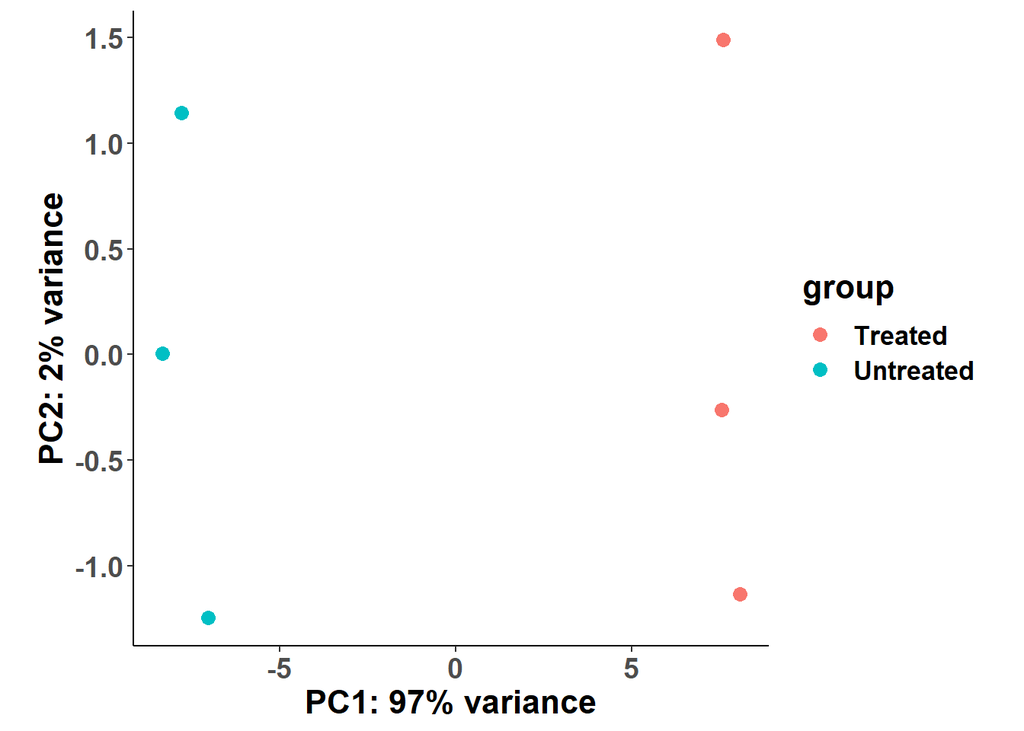

```r
deseq_vsd <- vst(deseq_run, blind = FALSE)
plotPCA(deseq_vsd, intgroup = c("treatment")) +
  theme_classic() +
  theme(
    aspect.ratio = 1,
    plot.title = element_text(hjust = 0.5),
    axis.text = element_text(size = 14, face = "bold"),
    axis.title = element_text(size = 16, face = "bold"),
    text = element_text(size = 16, face = "bold")
  )
```

PCA analysis weights the variables for each sample (here expression for each gene) to maximize the variance in the dataset and plots it along two axes - one for each PCA. Here you can see the first PCA captures the VAST majority of the variance - 97% - and also seperates out the treated from untreated groups, indicating that the treatment is the major source of varaiation in the data. You can see PC2 also captures a very small amount of variance, which may have more to do with batch/strain effects, here if each replicate was divided into two for treatment/no treatment, you can see those pairings line up on the PC2 axis. To reiterate, this effect is tiny compared to the treatment effect.

## 3. Volcano plot

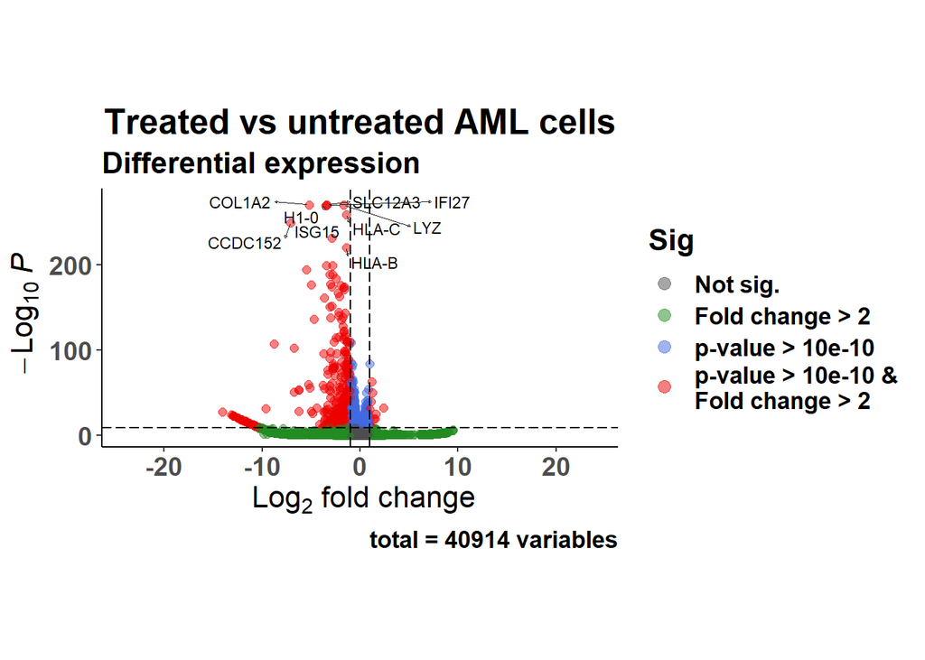

```r
# OLD PLOT
# ggplot(deseq_df, aes(-log2FoldChange, -log10(padj))) +
# geom_point() +
# xlab("Log2 Fold Change\n(<- untreated vs treated ->)") +
# ylab("-Log10 adjusted p-value") +
# theme_classic() +
# theme(plot.title = element_text(hjust = 0.5),
#     axis.text=element_text(size=14,face="bold"),
#     axis.title=element_text(size=16,face="bold"),
#     text=element_text(size=16,face="bold"))

deseq_df %>%
  EnhancedVolcano(
    lab = deseq_df$external_gene_name,
    x = "log2FoldChange",
    y = "padj",
    pCutoff = 10e-10,
    labSize = 3.0,
    drawConnectors = TRUE,
    widthConnectors = 0.25,
    legendPosition = "right",
    legendLabSize = 3,
    legendIconSize = 3.0,
    title = "Treated vs untreated AML cells",
    subtitle = "Differential expression",
    legendLabels = c(
      "Not sig.", "Fold change > 2", "p-value > 10e-10",
      "p-value > 10e-10 & \nFold change > 2"
    )
  ) +
  theme_classic() +
  theme(
    aspect.ratio = 0.5,
    plot.title = element_text(hjust = 0.5),
    axis.text = element_text(size = 14, face = "bold"),
    axis.title = element_text(size = 16, face = "bold"),
    text = element_text(size = 16, face = "bold"),
    legend.title = element_text("none")
  )
```

Here we plot the same differential expression data from the data table above in the form of a volcano plot - the farther out from 0 on the X-axis indicates a greater the difference between treatments, and the higher on the y-axis the more significant the difference. You can see from this plot that most of the significantly differentially expressed genes with a 2 or greater-fold difference (highlighted in red above) are downregulated - that is more highly expressed in untreated cells than treated ones.

## 4. Heatmap of DEGs

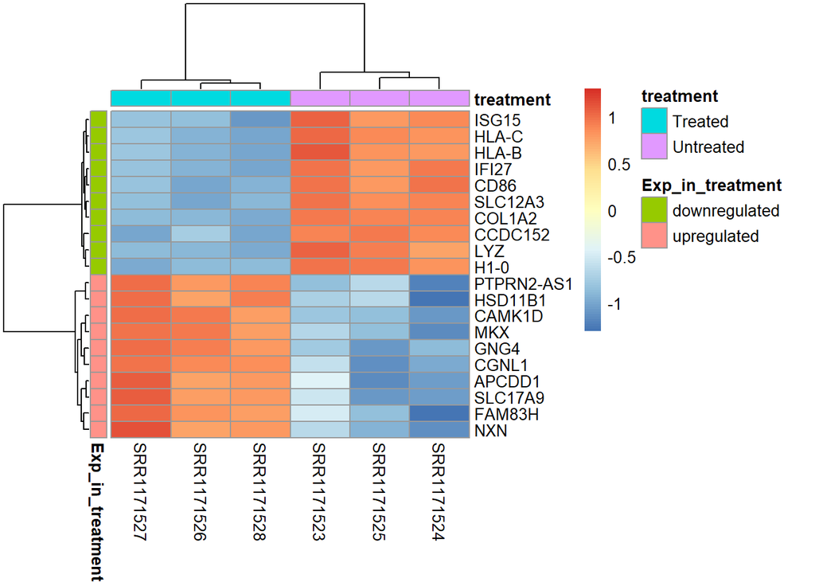

```r
# List of top 10 over- and under-expressed genes
downreg <- deseq_p0.05 %>%
  filter(log2FoldChange < 0) %>%
  head(n = 10) %>%
  pull(ensg)
upreg <- deseq_p0.05 %>%
  filter(log2FoldChange > 0) %>%
  head(n = 10) %>%
  pull(ensg)
# up_down <- c(downreg, upreg)
# up_down_labels <- data.frame(Exp_in_treatment = c(rep("downregulated", 10), rep("upregulated", 10)), row.names = up_down)

# Get assay data for top genes and translate names to gene symbols
topgenes <- assay(deseq_run)[downreg, ] %>%
  rbind(., assay(deseq_run)[upreg, ]) %>%
  log10()
deseq_df_names <- deseq_df %>%
  dplyr::select(external_gene_name, ensg) %>%
  column_to_rownames(var = "ensg")
rownames(topgenes) <- deseq_df_names[row.names(topgenes), ]

up_down_labels <- data.frame(Exp_in_treatment = c(rep("downregulated", 10), rep("upregulated", 10)), row.names = rownames(topgenes))

# Plot log-transformed heatmap

pheatmap(topgenes,
  cluster_rows = TRUE,
  show_rownames = TRUE,
  cluster_cols = TRUE,
  scale = "row",
  annotation_col = dplyr::select(data_treatments, treatment),
  annotation_row = up_down_labels
)
```

Here we take the the top 10 over-expressed DEGs (lowest adjusted p-values), and top 10 under-expressed DEGs and make a heatmap. A heatmap colors in each square according to the expression level for that gene, red indicated higher expression and blue indicating lower expression. Unsurprisingly, the clustering indicated by the trees on the edges indicate that the treatments cluster closer with one another (top - x-axis) and the gene sets that are up- or down-regulated cluster closely with one another (left - y-axis).